# Bayesian modeling and prediction for movies

TNMayer

2016-12-25

## Setup

### Load packages

```r
library(ggplot2)
library(dplyr)
library(statsr)
library(BAS)
```

### Load data

Make sure your data and R Markdown files are in the same directory. When loaded your data file will be called `movies`. Delete this note when before you submit your work.

```r
load("movies.Rdata")
#base_path <- getwd()
#path <- file.path(base_path, 'course04', 'movies.Rdata')
#load(path)
```

## Part 1: Data

**Instruction:** Describe how the observations in the sample are collected, and the implications of this data collection method on the scope of inference (generalizability / causality).

**Study design:** The data set is comprised of 651 randomly sampled movies produced and released before 2016.

Source: [Rotten Tomatoes](http://www.rottentomatoes.com/) and [IMDB](http://www.imdb.com/) APIs.

**Implications:** The described sampling methodology outlines a **random sampling but no random assignment**, hence it is an **Observational Study**. Each subject in the population is equally likely to be selected and the sample is likely representative for the aforementioned population. No random assignment means the study can provide **associations but no causation**. Random sampling means the findings of the study can be **generalized** to the population. The population is for this study: **all movies listed in the Rotten Tomatoes and IMDB databases**.

**Generalizability is given.**

**Causality is not given.**

## Part 2: Data manipulation

NOTE: Insert code chunks as needed by clicking on the “Insert a new code chunk” button above. Make sure that your code is visible in the project you submit. Delete this note when before you submit your work.

**Instructions:**

- Create new variable based on title_type: New variable should be called feature_film with levels yes (movies that are feature films) and no (2 pt)
- Create new variable based on genre: New variable should be called drama with levels yes (movies that are dramas) and no (2 pt)
- Create new variable based on mpaa_rating: New variable should be called mpaa_rating_R with levels yes (movies that are R rated) and no (2 pt)
- Create two new variables based on thtr_rel_month:
- New variable called oscar_season with levels yes (if movie is released in November, October, or December) and no (2 pt)
- New variable called summer_season with levels yes (if movie is released in May, June, July, or August) and no (2 pt)

```r
# create new variable feature_film
movies <- movies %>%
  mutate(feature_film = ifelse(title_type == "Feature Film", 'yes', 'no'))

movies$feature_film <- as.factor(movies$feature_film)

# create new variable drama
movies <- movies %>%
  mutate(drama = ifelse(genre == "Drama", 'yes', 'no'))

movies$drama <- as.factor(movies$drama)

# create variable mpaa_rating_R
movies <- movies %>%
  mutate(mpaa_rating_R = ifelse(mpaa_rating == "R", 'yes', 'no'))

movies$mpaa_rating_R <- as.factor(movies$mpaa_rating_R)

# create new variable oscar_season
movies <- movies %>%
  mutate(oscar_season = ifelse((thtr_rel_month %in% c(10:12)), 'yes', 'no'))

movies$oscar_season <- as.factor(movies$oscar_season)

# create new variable summer_season
movies <- movies %>%
  mutate(summer_season = ifelse((thtr_rel_month %in% c(5:8)), 'yes', 'no'))

movies$summer_season <- as.factor(movies$summer_season)
```

## Part 3: Exploratory data analysis

NOTE: Insert code chunks as needed by clicking on the “Insert a new code chunk” button above. Make sure that your code is visible in the project you submit. Delete this note when before you submit your work.

**Instructions:**

Conduct exploratory data analysis of the relationship between audience_score and the new variables constructed in the previous part.

- plots
- summary statistics
- narrative

```r
# Multiple plot function
#
# ggplot objects can be passed in ..., or to plotlist (as a list of ggplot objects)
# - cols:   Number of columns in layout
# - layout: A matrix specifying the layout. If present, 'cols' is ignored.
#
# If the layout is something like matrix(c(1,2,3,3), nrow=2, byrow=TRUE),
# then plot 1 will go in the upper left, 2 will go in the upper right, and
# 3 will go all the way across the bottom.
#
multiplot <- function(..., plotlist=NULL, file, cols=1, layout=NULL) {
  library(grid)

  # Make a list from the ... arguments and plotlist
  plots <- c(list(...), plotlist)

  numPlots = length(plots)

  # If layout is NULL, then use 'cols' to determine layout
  if (is.null(layout)) {
    # Make the panel
    # ncol: Number of columns of plots
    # nrow: Number of rows needed, calculated from # of cols
    layout <- matrix(seq(1, cols * ceiling(numPlots/cols)),
                    ncol = cols, nrow = ceiling(numPlots/cols))
  }

 if (numPlots==1) {
    print(plots[[1]])

  } else {
    # Set up the page
    grid.newpage()
    pushViewport(viewport(layout = grid.layout(nrow(layout), ncol(layout))))

    # Make each plot, in the correct location
    for (i in 1:numPlots) {
      # Get the i,j matrix positions of the regions that contain this subplot
      matchidx <- as.data.frame(which(layout == i, arr.ind = TRUE))

      print(plots[[i]], vp = viewport(layout.pos.row = matchidx$row,
                                      layout.pos.col = matchidx$col))
    }
  }
}
```

### Plots

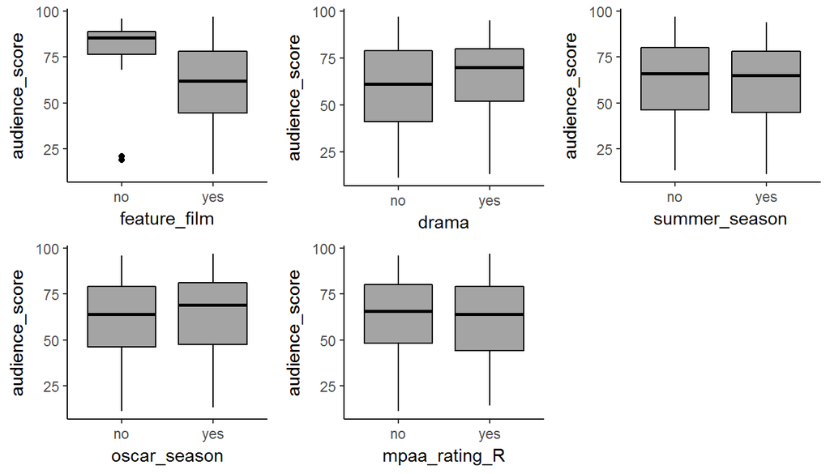

```r
# ggpairs(movies, columns = c(18, 33:37))
p1 <- ggplot(movies, aes(x=feature_film, y=audience_score)) +
        geom_boxplot(fill='#A4A4A4', color="black")+
        theme_classic()
p2 <- ggplot(movies, aes(x=oscar_season, y=audience_score)) +
        geom_boxplot(fill='#A4A4A4', color="black")+
        theme_classic()
p3 <- ggplot(movies, aes(x=drama, y=audience_score)) +
        geom_boxplot(fill='#A4A4A4', color="black")+
        theme_classic()
p4 <- ggplot(movies, aes(x=mpaa_rating_R, y=audience_score)) +
        geom_boxplot(fill='#A4A4A4', color="black")+
        theme_classic()
p5 <- ggplot(movies, aes(x=summer_season, y=audience_score)) +
        geom_boxplot(fill='#A4A4A4', color="black")+
        theme_classic()

multiplot(p1, p2, p3, p4, p5, cols=3)
```

Feature films tend to have a lower audience score than no feature films in general. Drama´s tend to have higher audience scores than no drama movies. There is no remarkable relationship in between summer season and non summer season movies as well as betwenn oscar season and non oscar season movies. There is also only a weak relationship identifyable between movies rated with “R” and movies not rated with “R” (MPAA rating). All categories tend to show a left skewed distribution on behalf of their audience scores.

### Summary Statistics

```r
movies %>%
  group_by(feature_film) %>%
  summarise(Mean = mean(audience_score), Median = median(audience_score), Min = min(audience_score),
            Max = max(audience_score), IQR = IQR(audience_score))
```

```
## # A tibble: 2 × 6
##   feature_film     Mean Median   Min   Max   IQR
##         <fctr>    <dbl>  <dbl> <dbl> <dbl> <dbl>
## 1           no 81.05000   85.5    19    96  12.5
## 2          yes 60.46531   62.0    11    97  33.5
```

```r
movies %>%
  group_by(drama) %>%
  summarise(Mean = mean(audience_score), Median = median(audience_score), Min = min(audience_score),
            Max = max(audience_score), IQR = IQR(audience_score))
```

```
## # A tibble: 2 × 6
##    drama     Mean Median   Min   Max   IQR
##   <fctr>    <dbl>  <dbl> <dbl> <dbl> <dbl>
## 1     no 59.73121     61    11    97    38
## 2    yes 65.34754     70    13    95    28
```

```r
movies %>%
  group_by(summer_season) %>%
  summarise(Mean = mean(audience_score), Median = median(audience_score), Min = min(audience_score),
            Max = max(audience_score), IQR = IQR(audience_score))
```

```
## # A tibble: 2 × 6
##   summer_season     Mean Median   Min   Max   IQR
##          <fctr>    <dbl>  <dbl> <dbl> <dbl> <dbl>
## 1            no 62.62302     66    13    97 34.00
## 2           yes 61.80769     65    11    94 33.25
```

```r
movies %>%
  group_by(oscar_season) %>%
  summarise(Mean = mean(audience_score), Median = median(audience_score), Min = min(audience_score),
            Max = max(audience_score), IQR = IQR(audience_score))
```

```
## # A tibble: 2 × 6
##   oscar_season     Mean Median   Min   Max   IQR
##         <fctr>    <dbl>  <dbl> <dbl> <dbl> <dbl>
## 1           no 61.81304     64    11    96  33.0
## 2          yes 63.68586     69    13    97  33.5
```

```r
movies %>%
  group_by(mpaa_rating_R) %>%
  summarise(Mean = mean(audience_score), Median = median(audience_score), Min = min(audience_score),
            Max = max(audience_score), IQR = IQR(audience_score))
```

```
## # A tibble: 2 × 6
##   mpaa_rating_R     Mean Median   Min   Max   IQR
##          <fctr>    <dbl>  <dbl> <dbl> <dbl> <dbl>
## 1            no 62.68944   65.5    11    96 31.75
## 2           yes 62.04255   64.0    14    97 35.00
```

The same patterns as described above are also observable by the summary statistics. There is a quite big difference between the feature_film groups according to their average audience scores. Their is also a difference of roughly 6 points on average between the drama groups. The differences in the mean audience scores between the oscar_season, summer_season as well as mpaa_rating_R groups are not worth to mention. Hence the feature_film and drama variables should be able to differentiate well between high and low audience scores. How strong the new variables will influence the linear regression model will be observed in the next chapter.

## Part 4: Modeling

NOTE: Insert code chunks as needed by clicking on the “Insert a new code chunk” button above. Make sure that your code is visible in the project you submit. Delete this note when before you submit your work.

**Instruction:**

Develop a Bayesian regression model to predict audience_score from the following explanatory variables. Note that some of these variables are in the original dataset provided, and others are new variables you constructed earlier.

Complete Bayesian model selection and report the final model.

- Carrying out the model selection correctly (5 pts)
- Model diagnostics (5 pts)
- Interpretation of model coefficients (5 pts)

**Create the full model:**

```r
# select the needed variables (dependent and independent)
movies_model <- dplyr::select(movies, audience_score, feature_film, drama, runtime, mpaa_rating_R, thtr_rel_year, oscar_season, summer_season, imdb_rating, imdb_num_votes, critics_score, best_pic_nom, best_pic_win, best_actor_win, best_actress_win, best_dir_win, top200_box)

m_movies_full = lm(audience_score ~ ., data = movies_model)

# print out the model summary
summary(m_movies_full)
```

```
##
## Call:
## lm(formula = audience_score ~ ., data = movies_model)
##
## Residuals:
##     Min      1Q  Median      3Q     Max
## -28.594  -6.156   0.157   5.909  53.125
##
## Coefficients:
##                       Estimate Std. Error t value Pr(>|t|)
## (Intercept)          1.244e+02  7.749e+01   1.606  0.10886
## feature_filmyes     -2.248e+00  1.687e+00  -1.332  0.18323
## dramayes             1.292e+00  8.766e-01   1.474  0.14087
## runtime             -5.614e-02  2.415e-02  -2.324  0.02042 *
## mpaa_rating_Ryes    -1.444e+00  8.127e-01  -1.777  0.07598 .
## thtr_rel_year       -7.657e-02  3.835e-02  -1.997  0.04628 *
## oscar_seasonyes     -5.333e-01  9.967e-01  -0.535  0.59280
## summer_seasonyes     9.106e-01  9.493e-01   0.959  0.33778
## imdb_rating          1.472e+01  6.067e-01  24.258  < 2e-16 ***
## imdb_num_votes       7.234e-06  4.523e-06   1.600  0.11019
## critics_score        5.748e-02  2.217e-02   2.593  0.00973 **
## best_pic_nomyes      5.321e+00  2.628e+00   2.025  0.04330 *
## best_pic_winyes     -3.212e+00  4.610e+00  -0.697  0.48624
## best_actor_winyes   -1.544e+00  1.179e+00  -1.310  0.19068
## best_actress_winyes -2.198e+00  1.304e+00  -1.686  0.09229 .
## best_dir_winyes     -1.231e+00  1.728e+00  -0.713  0.47630
## top200_boxyes        8.478e-01  2.782e+00   0.305  0.76067
## ---
## Signif. codes:  0 '***' 0.001 '**' 0.01 '*' 0.05 '.' 0.1 ' ' 1
##
## Residual standard error: 9.975 on 633 degrees of freedom
##   (1 observation deleted due to missingness)
## Multiple R-squared:  0.763,  Adjusted R-squared:  0.757
## F-statistic: 127.3 on 16 and 633 DF,  p-value: < 2.2e-16
```

```r
# get the BIC score of the full model
BIC(m_movies_full)
```

```
## [1] 4934.145
```

This shows that initially only seven out of 16 model weights differ significantly from 0. The Bayesian Information Criterion (BIC) of the full model is 4934.145. The goal of the following model selection process is to minimize the BIC. The adjusted $R^2$ value of the model is 0.757. A higher adjusted $R^2$ value indicates a better predictive value of the model and draws the number of independent variables into account.

Before performing the model selection process let´s have a look at the model assumptions.

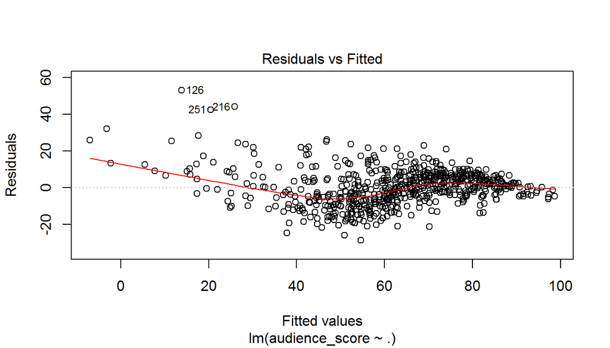

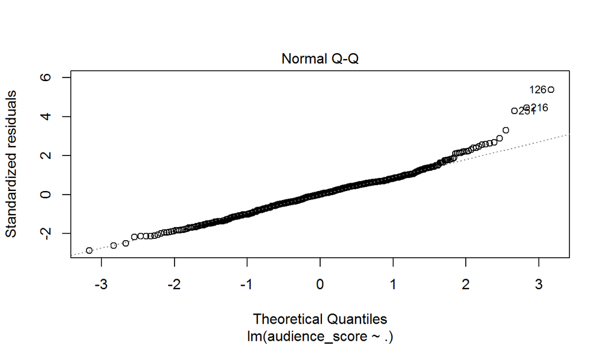

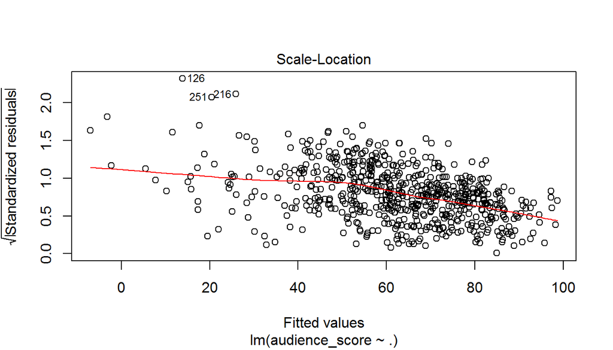

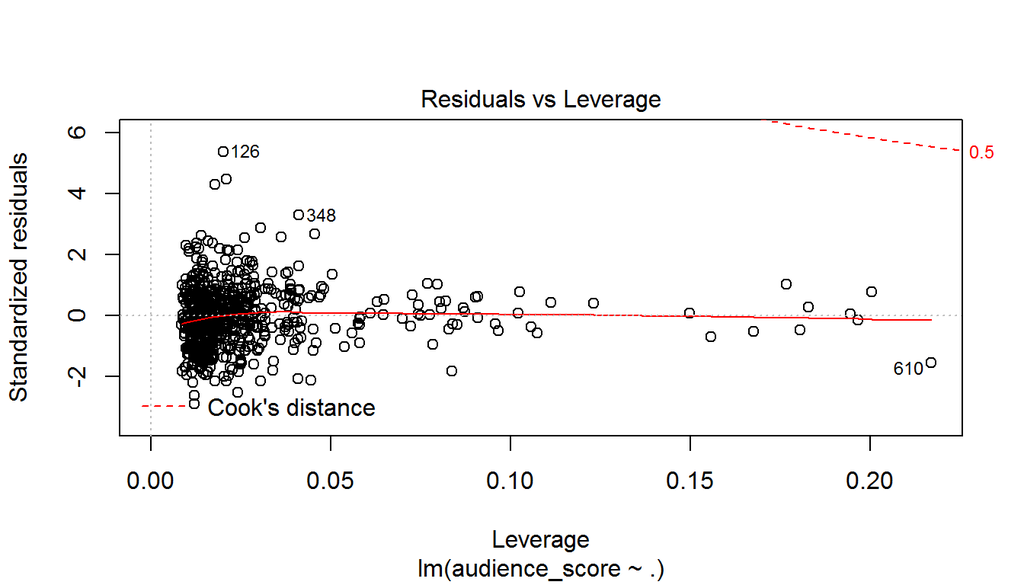

```r
plot(m_movies_full)
```

The distribution of the residuals seems to be right-skewed. One reason for that might be that the dependent variable of the model (audience score) is left skewed. Maybe a transformation of the variable can help to normalize the plot. One way to overcome the the skewness could be a flipped log transformation. But the Q-Q-Plot doesn´t look extremely bad, so the model selection process will be performed next.

Now the model selection process is performed using the stepAIC-function out of the MASS package. In order to find the model with the lowest BIC the penalty parameter k has to be adjusted as follows: $k = \log(n)$.

```r
library(MASS)
m_movies_full = lm(audience_score ~ ., data = na.omit(movies_model))
m_movies.step <- stepAIC(m_movies_full, trace = T, k = log(nrow(movies_model)))
```

```
## Start:  AIC=3083.07
## audience_score ~ feature_film + drama + runtime + mpaa_rating_R +
##     thtr_rel_year + oscar_season + summer_season + imdb_rating +
##     imdb_num_votes + critics_score + best_pic_nom + best_pic_win +
##     best_actor_win + best_actress_win + best_dir_win + top200_box
##
##                    Df Sum of Sq    RSS    AIC
## - top200_box        1         9  62999 3076.7
## - oscar_season      1        28  63018 3076.9
## - best_pic_win      1        48  63038 3077.1
## - best_dir_win      1        51  63040 3077.1
## - summer_season     1        92  63081 3077.5
## - best_actor_win    1       171  63160 3078.4
## - feature_film      1       177  63166 3078.4
## - drama             1       216  63206 3078.8
## - imdb_num_votes    1       255  63244 3079.2
## - best_actress_win  1       283  63273 3079.5
## - mpaa_rating_R     1       314  63304 3079.8
## - thtr_rel_year     1       397  63386 3080.7
## - best_pic_nom      1       408  63398 3080.8
## - runtime           1       538  63527 3082.1
## <none>                           62990 3083.1
## - critics_score     1       669  63659 3083.5
## - imdb_rating       1     58556 121545 3503.9
##
## Step:  AIC=3076.69
## audience_score ~ feature_film + drama + runtime + mpaa_rating_R +
##     thtr_rel_year + oscar_season + summer_season + imdb_rating +
##     imdb_num_votes + critics_score + best_pic_nom + best_pic_win +
##     best_actor_win + best_actress_win + best_dir_win
##
##                    Df Sum of Sq    RSS    AIC
## - oscar_season      1        26  63025 3070.5
## - best_pic_win      1        49  63047 3070.7
## - best_dir_win      1        52  63051 3070.8
## - summer_season     1        94  63093 3071.2
## - best_actor_win    1       169  63168 3072.0
## - feature_film      1       176  63175 3072.0
## - drama             1       214  63213 3072.4
## - best_actress_win  1       279  63278 3073.1
```

[output cut: 185 more lines]

```
##                 Df Sum of Sq    RSS    AIC
## - mpaa_rating_R  1       361  65126 3020.5
## - runtime        1       638  65403 3023.3
## <none>                        64765 3023.4
## - critics_score  1      1027  65792 3027.1
## - imdb_rating    1     68173 132937 3484.3
##
## Step:  AIC=3020.53
## audience_score ~ runtime + imdb_rating + critics_score
##
##                 Df Sum of Sq    RSS    AIC
## <none>                        65126 3020.5
## - runtime        1       653  65779 3020.5
## - critics_score  1      1073  66199 3024.7
## - imdb_rating    1     67874 133000 3478.2
```

The model selection process shows that the minimum BIC/AIC value can be achieved by a model with only three independent variables (runtime, imdb_rating and critics_score). Let´s have a look on the summary statistics and the BIC of the model.

```r
summary(m_movies.step)
```

```
##
## Call:
## lm(formula = audience_score ~ runtime + imdb_rating + critics_score,
##     data = na.omit(movies_model))
##
## Residuals:
##     Min      1Q  Median      3Q     Max
## -26.998  -6.565   0.557   5.475  52.448
##
## Coefficients:
##                Estimate Std. Error t value Pr(>|t|)
## (Intercept)   -33.28321    3.21939 -10.338  < 2e-16 ***
## runtime        -0.05362    0.02107  -2.545  0.01117 *
## imdb_rating    14.98076    0.57735  25.947  < 2e-16 ***
## critics_score   0.07036    0.02156   3.263  0.00116 **
## ---
## Signif. codes:  0 '***' 0.001 '**' 0.01 '*' 0.05 '.' 0.1 ' ' 1
##
## Residual standard error: 10.04 on 646 degrees of freedom
## Multiple R-squared:  0.7549, Adjusted R-squared:  0.7538
## F-statistic: 663.3 on 3 and 646 DF,  p-value: < 2.2e-16
```

```r
BIC(m_movies.step)
```

```
## [1] 4871.623
```

Let´s have a short look on the model coefficients. To give a short explanation I will focus on the coefficient for the imdb_rating variable with a coefficient value of 14.98. This means, holding all other variables in the model constant, a movie with one point more in the imdb_rating is expected to increase the audience score by 14.98 points. The range for imdb_rating scores is [1.9; 9.0].

Now let´s have a look at the model diagnostics by having a look on the residual plots:

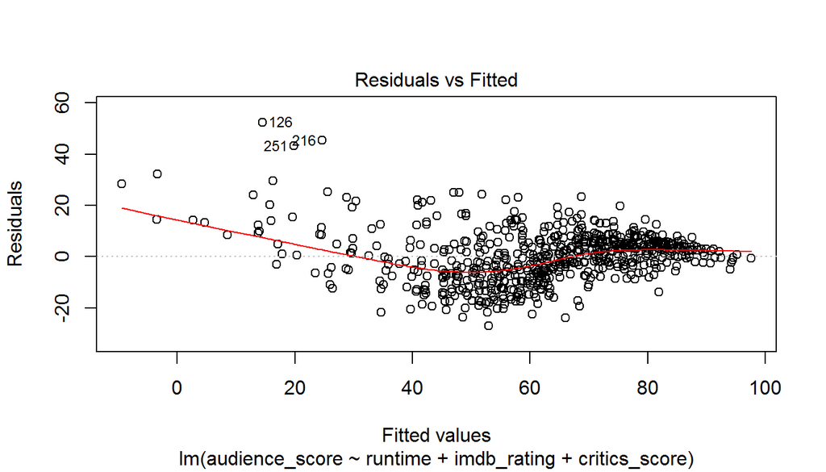

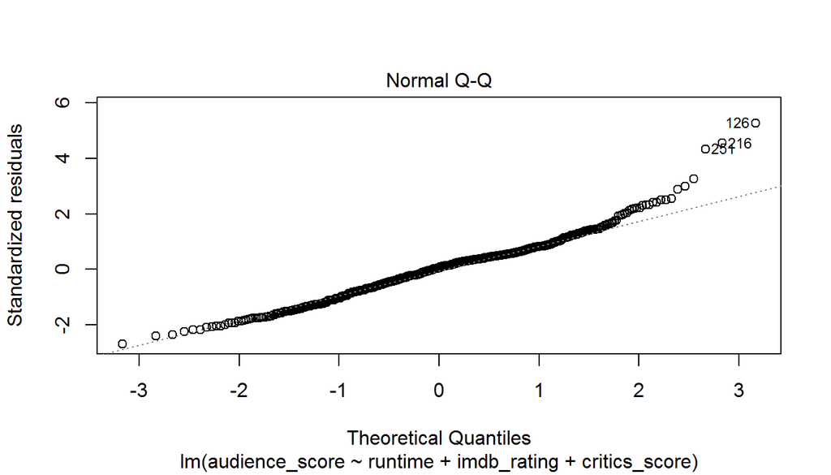

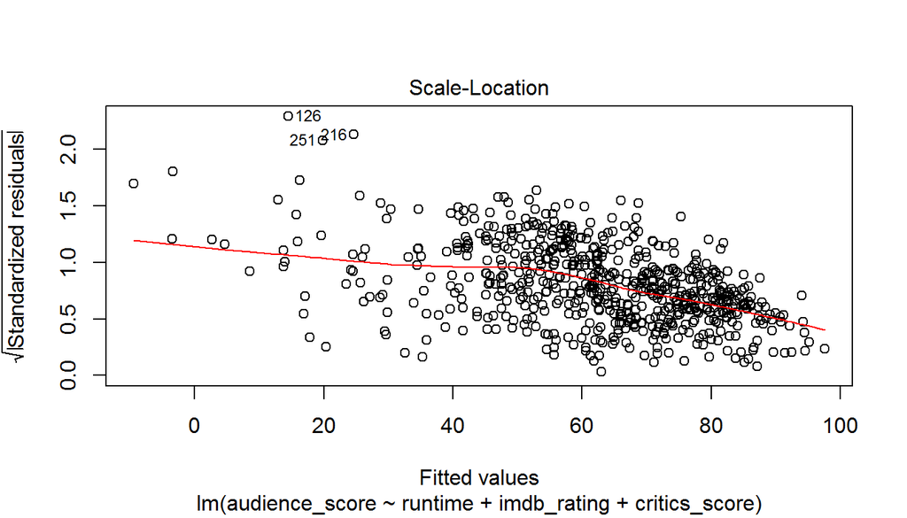

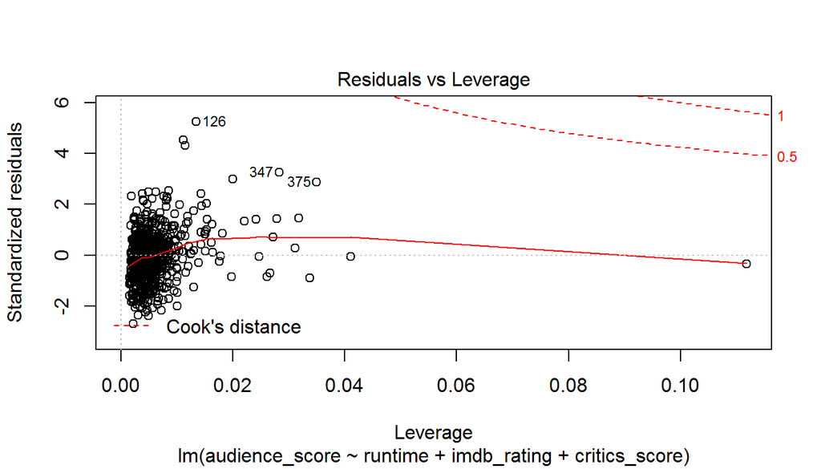

```r
plot(m_movies.step)
```

The residual plot still appears to be right skewed but it doesn´t look extremely bad. One way to overcome this kind of problem could be by normalizing the included variables by transformation. Let´s have a look on the variable distributions:

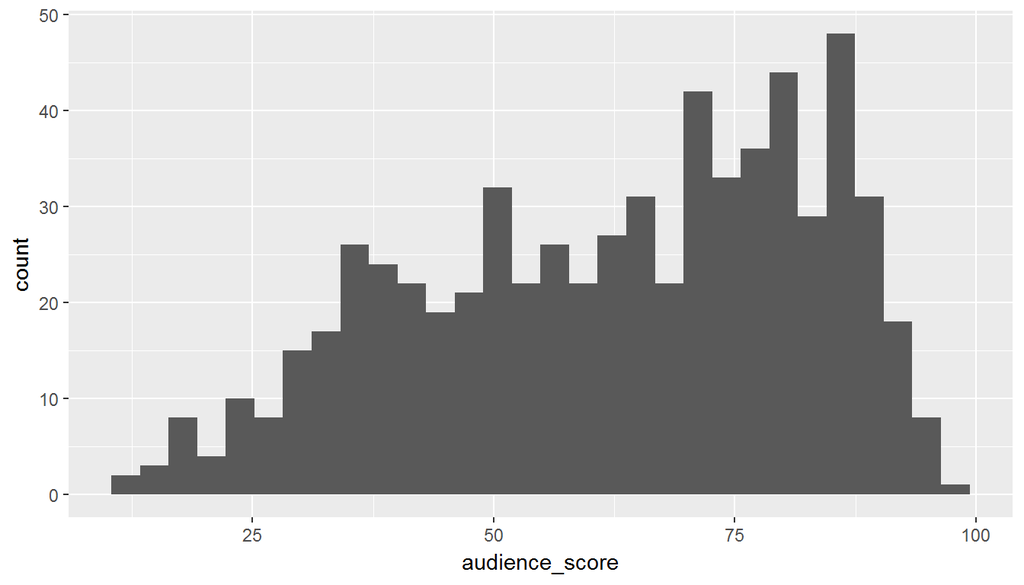

```r
ggplot(data = movies_model, aes(x = audience_score)) + geom_histogram()
```

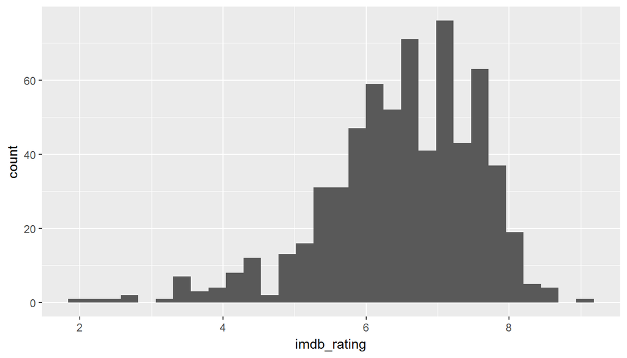

```r
ggplot(data = movies_model, aes(x = imdb_rating)) + geom_histogram()
```

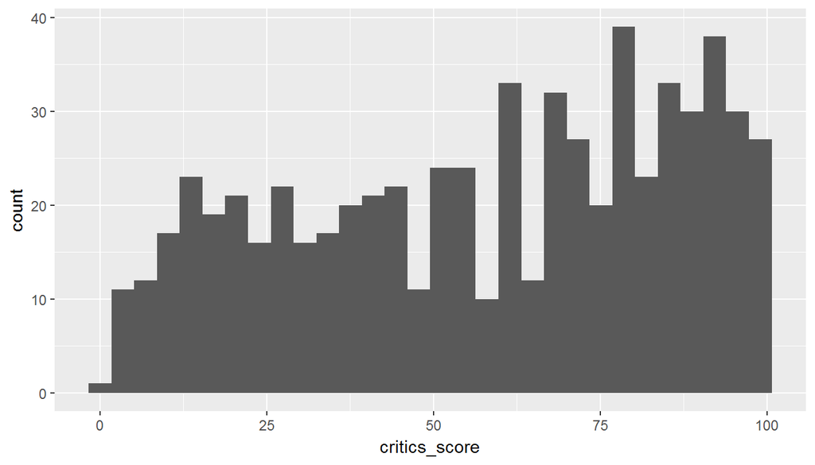

```r
ggplot(data = movies_model, aes(x = critics_score)) + geom_histogram()
```

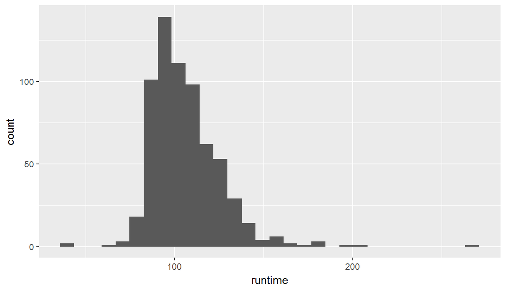

```r
ggplot(data = movies_model, aes(x = runtime)) + geom_histogram()
```

### Bayesian Model Averaging (BMA)

Before predicting the audience score for new movies I want to apply a model selection process by Bayesian Model Averaging first. I don´t want to ignore the inherent uncertainty involved in choosing the variables to include in the model.

```r
# exclude NA values from the data
movies_nona <- na.omit(movies_model)
bma_audience = bas.lm(audience_score ~ ., data = movies_nona,
                   prior = "BIC",
                   modelprior = uniform())
bma_audience
```

```
##
## Call:
## bas.lm(formula = audience_score ~ ., data = movies_nona, prior = "BIC",     modelprior = uniform())
##
##
##  Marginal Posterior Inclusion Probabilities:
##           Intercept      feature_filmyes             dramayes
##             1.00000              0.06537              0.04320
##             runtime     mpaa_rating_Ryes        thtr_rel_year
##             0.46971              0.19984              0.09069
##     oscar_seasonyes     summer_seasonyes          imdb_rating
##             0.07506              0.08042              1.00000
##      imdb_num_votes        critics_score      best_pic_nomyes
##             0.05774              0.88855              0.13119
##     best_pic_winyes    best_actor_winyes  best_actress_winyes
##             0.03985              0.14435              0.14128
##     best_dir_winyes        top200_boxyes
##             0.06694              0.04762
```

```r
summary(bma_audience)
```

```
##      Intercept feature_filmyes dramayes runtime mpaa_rating_Ryes
## [1,]         1               0        0       1                0
## [2,]         1               0        0       0                0
## [3,]         1               0        0       0                0
## [4,]         1               0        0       0                1
## [5,]         1               0        0       1                1
##      thtr_rel_year oscar_seasonyes summer_seasonyes imdb_rating
## [1,]             0               0                0           1
## [2,]             0               0                0           1
## [3,]             0               0                0           1
## [4,]             0               0                0           1
## [5,]             0               0                0           1
##      imdb_num_votes critics_score best_pic_nomyes best_pic_winyes
## [1,]              0             1               0               0
## [2,]              0             1               0               0
## [3,]              0             1               0               0
## [4,]              0             1               0               0
## [5,]              0             1               0               0
##      best_actor_winyes best_actress_winyes best_dir_winyes top200_boxyes
## [1,]                 0                   0               0             0
## [2,]                 0                   0               0             0
## [3,]                 1                   0               0             0
## [4,]                 0                   0               0             0
## [5,]                 0                   0               0             0
##             BF PostProbs     R2 dim   logmarg
## [1,] 1.0000000    0.1297 0.7549   4 -3615.279
## [2,] 0.9968489    0.1293 0.7525   3 -3615.282
## [3,] 0.2543185    0.0330 0.7539   4 -3616.648
## [4,] 0.2521327    0.0327 0.7539   4 -3616.657
## [5,] 0.2391994    0.0310 0.7563   5 -3616.710
```

Now let´s have a look on the predictor variables of the BMA best predictive model (BPM).

```r
BPM_pred_audience <- predict(bma_audience, estimator = "BPM", se.fit = T)
bma_audience$namesx[BPM_pred_audience$bestmodel + 1]
```

```
## [1] "Intercept"     "runtime"       "imdb_rating"   "critics_score"
```

Also the best predictive model by BMA yields the same predictor variables as the model selected by the stepAIC function from the MASS package that works backwards through the model space, removing variables until BIC can be no longer lowered.

## Part 5: Prediction

NOTE: Insert code chunks as needed by clicking on the “Insert a new code chunk” button above. Make sure that your code is visible in the project you submit. Delete this note when before you submit your work.

**Instructions:**

Pick a movie from 2016 (a new movie that is not in the sample) and do a prediction for this movie using your the model you developed and the predict function in R.

- Correct prediction (4 pts)
- Reference(s) for where the data for this movie come from (1 pt)

In order to be able to predict the dependent/response variable for a movie from 2016 I first have to get the scores for the independent/explanatory variables. Those variables are:

I selected the movie The Accountant from 2016.

| variable | score |
| --- | --- |
| `imdb_rating` | 7.5 |
| `runtime` | 128 |
| `critics_score` | 52 |

The movie achieved an audience score of 81 % on Rotten Tomatoes.

Source: [Rotten Tomatoes](http://www.rottentomatoes.com/) and [IMDB](http://www.imdb.com/) APIs.

Now I want to observe how well the model will be able to predict the audience score of the Accountant.

First, I need to create a new data frame for this movie.

```r
newmovie <- data.frame(imdb_rating = 7.5, runtime = 128,
                       critics_score = 52)

# IOT make a prediction we have to fit a new prediction model with only the three best
# predictor variables included
# the already fitted m_movies.step model from above includes those variables and can be drawn into account
predict(m_movies.step, newdata = newmovie, interval = "prediction", level = 0.95)
```

```
##        fit      lwr      upr
## 1 75.86833 56.08264 95.65402
```

Hence, the model predicts, with 95% confidence, that a movie with an imdb_rating of 7.5, a runtime of 128 minutes and a critics_score of 52 % is expected to have an audience score on Rotten Tomatoes between 56.08264 and 95.65402. The current audience score for the movie The Accountant on Rotten Tomatoes is 81 % what is pretty close to the predicted value of 75.86833.

## Part 6: Conclusion

**Instructions:**

A brief summary of your findings from the previous sections without repeating your statements from earlier as well as a discussion of what you have learned about the data and your research question. You should also discuss any shortcomings of your current study (either due to data collection or methodology) and include ideas for possible future research.

- Conclusion not repetitive of earlier statements (1 pt)
- Cohesive synthesis of findings that appropriate address the research question stated earlier (1 pt)
- Discussion of shortcomings (1 pt)

Altogether five new variables were derived from the movies dataset. The task was to learn about what attributes make a movie popular. In order to answer this question a Bayesian regression model was developed to predict audience_score from 16 explanatory variables included in the full movies dataset (old variables and additionally derived variables). The best predictive model derived from Bayesian Model Averaging and a stepAIC process kept three explanatory variables in the final model:

- imdb_rating
- critics_score
- runtime

The newly derived variables from the original data were not able to gain any additional predictive value after a BMA model selection process. The goal of every statistical modeling approach is a high generalizability to unknown data and final model should therefore be as sparse as possible according to Ockham´s Razor principle. Hence only three variables were kept in the final model.

The prediction results achieved by the model are promisingly and can be assessed as overall good. The random sample from the Rotten Tomatoes and IMDb API´s is large enough to achieve good research results. Nevertheless neither the dependent nor the independent variables were normal distributed and hence the provieded data slightly violated the model assumptions in terms of linear regression models (e.g. normally distributed errors). Further data transformation procedures weren´t very promisingly. Therefore other modeling approaches without those strict assumptions should be included in future research approaches (e.g. kNN-regression, SVM regression, generalized additive models, etc.).